# Data Analysis For Users Segmentation of Ford-gobike Dataset.

### by Mohamed Sayed

## Investigation Overview

The aim of this presentation is to extract insights that will help the company to better exploit the resources and prioritize its segmentations and users by distinguishing the dominant behavior of different users.

## Dataset Overview

The dataset is extracted from the publically-published FORD-GOBIKE dataset. This Analysis focuses on the first 6 months of the year 2018.

# How much distance are the bikes often used for?

**The upcoming graph shows the distribution of the distances traveled by the members. and the following could be concluded:**

1. Most renters use the bikes for relatively **short distances (< 2km).**
2. There are very few bikers who are traveling long distances, this shows that the bikes, overall, are just **used for minor purposes,** probably just commuting to work or school.  
   **So, companies shouldn't focus their production lines on highly sophisticated bikes, rather, medium and adequate products.**

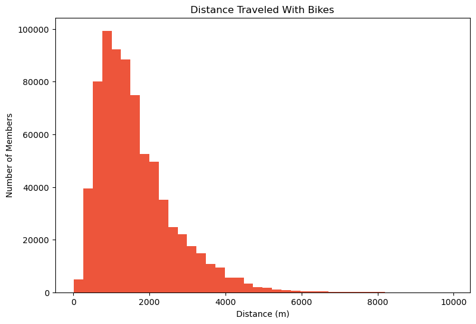

## Which category of members is the most distinguished?

**Another interesting information that the data suggests also is:**

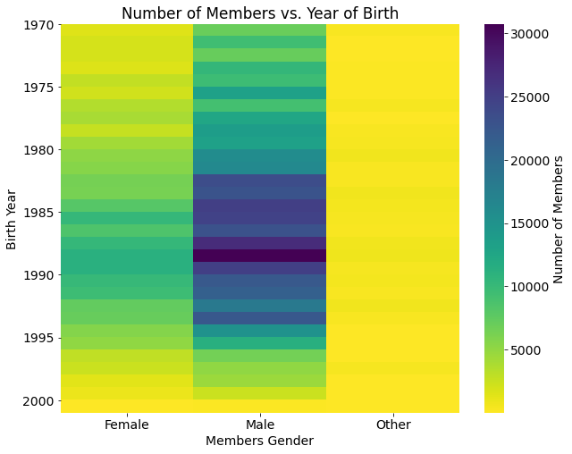

### Deeper into the Gender vs. Age Relation:

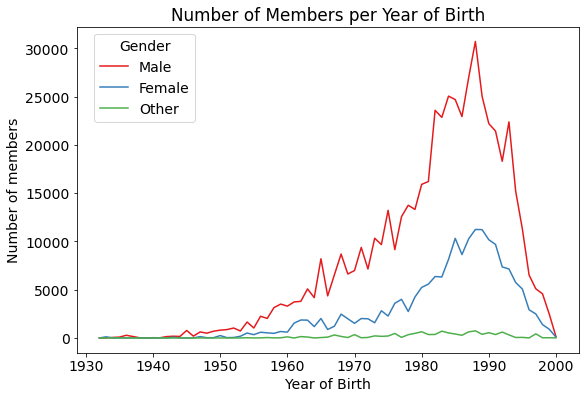